# Summary of Storm Data from 1950 to 2011 and its Costs

Jeffrey Norton, Ph.D.

March 10, 2017

A PDF of this report may be downloaded from [github](https://github.com/jeffreyrnorton/StormEventStudy/raw/master/StormDataStudy.pdf).

# Original Data

The original data is [here](https://d396qusza40orc.cloudfront.net/repdata%2Fdata%2FStormData.csv.bz2) and the National Weather Service Storm Data Documentation is [here](https://d396qusza40orc.cloudfront.net/repdata%2Fpeer2_doc%2Fpd01016005curr.pdf). The events in the database span from 1950 and end in November 2011. The data from earlier years is sparse with fewer recorded events. The data from more recent years is considered more complete.

# Data Processing

[Download](https://d396qusza40orc.cloudfront.net/repdata%2Fdata%2FStormData.csv.bz2) and unzip the CSV file. Read the table into a data table representing the raw storm data.

```r
StormData <- read.csv(file="repdata%2Fdata%2FStormData.csv", header=TRUE)
```

## Data Analysis

The steps taken in the data analysis are the following:

1. Determine and summarize the worst storm type for fatalities and injuries for all the United States from 1950 to 2011.
2. Determine and summarize the worst storm type for property and crop damage in dollars for all the Unites States from 1950 to 2011.
3. For each state (which includes US States, marine regions, etc.), determine a maximum of the three most costly storms with respect to fatalities, injuries, property, and crop damage.

# Results

## Fatalities and Injuries

Determine the worst Storm Type for fatalities and injuries across the United States.

```r
# For ease, create named vectors of the fatalities/injuries.
evtype <- unique(StormData$EVTYPE)
event.fatalities <- integer(length=length(evtype))
event.injuries   <- integer(length=length(evtype))
i <- 1
for( event in evtype ) {
  s <- sum(StormData[StormData$EVTYPE==event,]$FATALITIES)
  event.fatalities[i] <- s
  s <- sum(StormData[StormData$EVTYPE==event,]$INJURIES)
  event.injuries[i] <- s
  i <- i+1
}
names(event.fatalities) <- unique(StormData$EVTYPE)
names(event.injuries) <- unique(StormData$EVTYPE)

# Get max fatalities and injuries...
worst.f <- which(event.fatalities==max(event.fatalities))
worst.i <- which(event.injuries==max(event.injuries))
worst.fatal.name <- names(event.fatalities[worst.f])
worst.injury.name <- names(event.injuries[worst.i])
print(sprintf("Event and Count: Worst Fatalities: %s=%d.  Worst Injuries: %s=%d",
      worst.fatal.name, as.integer(event.fatalities[worst.f]),
      worst.injury.name, as.integer(event.injuries[worst.i])))
```

```
## [1] "Event and Count: Worst Fatalities: TORNADO=5633.  Worst Injuries: TORNADO=91346"
```

The worst storm type is TORNADO with 5,633 fatalities and TORNADO with 91,346 injuries (total from 1950 to 2011).

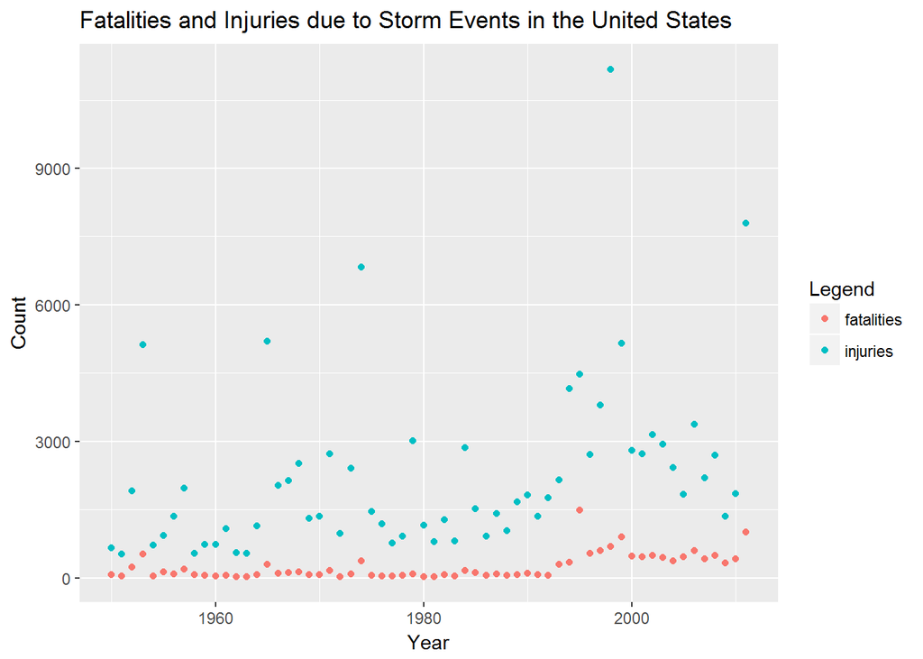

```r
# Add a year column to StormData (since we will use it three times...)
StormData[["YEARY"]] <-
  as.numeric(format(as.Date(vapply(strsplit(as.character(StormData$BGN_DATE), split=" "),
                                   '[', 1, FUN.VALUE=character(1)), format="%m/%d/%Y"), "%Y"))
# Create a data.frame with the year and the sum of each years fatalities...
unique.years <- unique(StormData[["YEARY"]])
fatality.sum <- injury.sum <- numeric(length(unique.years))
i <- 1
for( y in unique.years ) {
  fatality.sum[i] = sum(StormData[StormData$YEARY==y,]$FATALITIES)
  injury.sum[i] = sum(StormData[StormData$YEARY==y,]$INJURIES)
  i <- i+1
}
plot.df <- data.frame(unique.years, fatality.sum, injury.sum)
colnames(plot.df) <- c("year", "fatalities", "injuries")
# Now create a ggplot using the data frame
library(ggplot2)
library(tidyr)
print(
  plot.df %>%
    gather(Legend,Count, fatalities, injuries) %>%
    ggplot(aes(x=year,y=Count,color=Legend)) + geom_point() +
    labs(x="Year") + ggtitle("Fatalities and Injuries due to Storm Events in the United States"))
```

## Storm damage (property and crop)

Determine the worst Storm Type for property and crop damage in dollars across the United States.

### Interpreting Property and Crop Damage Amounts

```r
# Calculate property and crop damage.  We need to set up an exponent table
# because the exponents are crazy for these entries:
# K M   B m + 0 5 6 ? 4 2 3 h 7 H - 1 8 ? 0 2 B k K m M
# Some make absolutely no sense, so we have to guess them.
# The documentation is of no use for the strange entries.
available.exponents <- unique(c(as.character(unique(StormData$CROPDMGEXP)),
                                as.character(unique(StormData$PROPDMGEXP))))
writeLines(sprintf("All used exponents for cost values:\n%s",
                   paste(available.exponents, collapse=", ")))
```

```
## All used exponents for cost values:
## , M, K, m, B, ?, 0, k, 2, +, 5, 6, 4, 3, h, 7, H, -, 1, 8
```

```r
# The following list includes all the above plus an extra small "b" for billions.
exponent.lookup <- list(K=3, M=6, "1"=1, "2"=2, "3"=3, "4"=4, "5"=5,
                        "6"=6, "7"=7, "8"=8, "9"=9, B=9, m=6,
                        "0"=1, "+"=1, "-"=1, k=3, b=9, "?"=1, h=3, H=3)
# Get something printable with kable
exponent.lookup.df <- data.frame(unlist(exponent.lookup))
colnames(exponent.lookup.df) <- c("Exponent Value")
```

|  | Exponent Value |
| --- | --- |
| K | 3 |
| M | 6 |
| 1 | 1 |
| 2 | 2 |
| 3 | 3 |
| 4 | 4 |
| 5 | 5 |
| 6 | 6 |
| 7 | 7 |
| 8 | 8 |
| 9 | 9 |
| B | 9 |
| m | 6 |
| 0 | 1 |
| + | 1 |
| - | 1 |
| k | 3 |
| b | 9 |
| ? | 1 |
| h | 3 |
| H | 3 |

Given these assumptions, calculate property and cost damage.

```r
l <- as.character(StormData$PROPDMGEXP)
l[which(l=="")] <- "1"
for( e in unique(l) ) {
  l[which(l==e)] <- exponent.lookup[[e]]
}
prop.damage <- StormData$PROPDMG * 10^(as.integer(l))
l <- as.character(StormData$CROPDMGEXP)
l[which(l=="")] <- "1"
for( e in unique(l) ) {
  l[which(l==e)] <- exponent.lookup[[e]]
}
crop.damage <- StormData$CROPDMG * 10^(as.integer(l))

# Store the property and crop damage values into the StormData data.frame as
# we will be using it from here on out.
StormData[["PROPDMGC"]] <- prop.damage
StormData[["CROPDMGC"]] <- crop.damage

event.prop.damage <- integer(length=length(evtype))
event.crop.damage <- integer(length=length(evtype))
i <- 1
for( event in evtype ) {
  s <- sum(StormData[StormData$EVTYPE==event,]$PROPDMGC)
  event.prop.damage[i] <- s
  s <- sum(StormData[StormData$EVTYPE==event,]$CROPDMGC)
  event.crop.damage[i] <- s
  i <- i+1
}
names(event.prop.damage) <- unique(StormData$EVTYPE)
names(event.crop.damage) <- unique(StormData$EVTYPE)

# Get max property damage...
worst.p <- which(event.prop.damage==max(event.prop.damage))
worst.c <- which(event.crop.damage==max(event.crop.damage))
worst.p.name <- names(event.prop.damage[worst.p])
worst.c.name <- names(event.crop.damage[worst.c])
writeLines(sprintf(
  "Event and Count:\nWorst Property Damage: %s=$%15.2f.\nWorst Crop Damage: %s=$%15.2f",
      worst.p.name, as.numeric(event.prop.damage[worst.p]),
      worst.c.name, as.numeric(event.crop.damage[worst.c])))
```

```
## Event and Count:
## Worst Property Damage: FLOOD=$144657709870.00.
## Worst Crop Damage: DROUGHT=$ 13972566000.00
```

For property damage, the worst storm type is FLOOD with 144,657,709,870 dollars damage. For crop damage, the worst storm type is DROUGHT with 13,972,566,000 dollars damage. Both values are the sum of all events from 1950 to 2011.

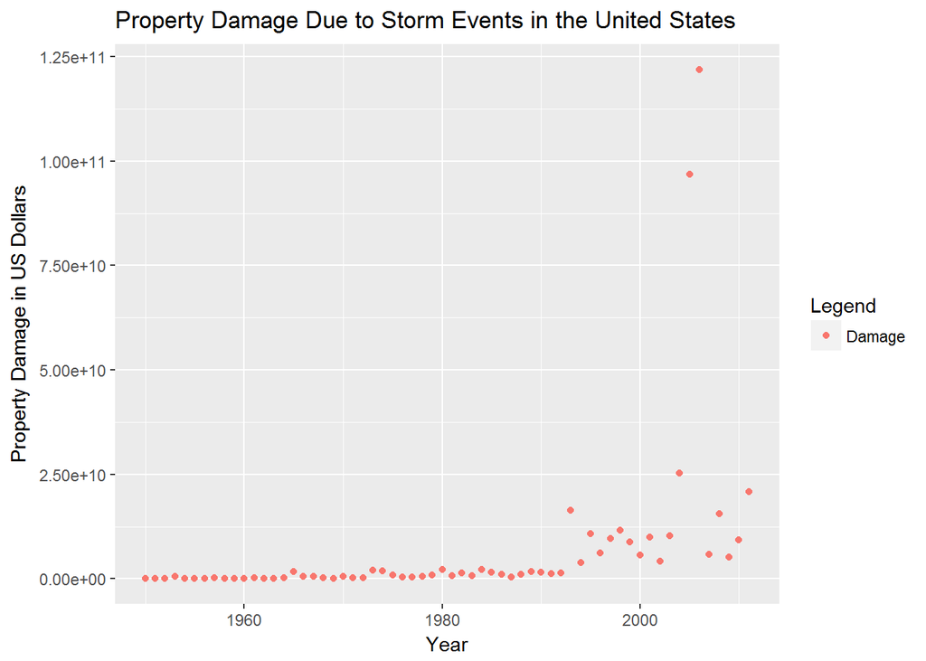

```r
Damage <- numeric(length(unique.years))
i <- 1

for( y in unique.years ) {
  Damage[i] = sum(StormData[StormData$YEARY==y,]$PROPDMGC)
  i <- i+1
}
plot.df <- data.frame(unique.years, Damage)
colnames(plot.df) <- c("year", "Damage")
# Now create a ggplot with the data frame
print(
  plot.df %>%
    gather(Legend,Count, Damage) %>%
    ggplot(aes(x=year,y=Count,color=Legend)) + geom_point() +
    labs(x="Year", y="Property Damage in US Dollars") +
    ggtitle("Property Damage Due to Storm Events in the United States"))
```

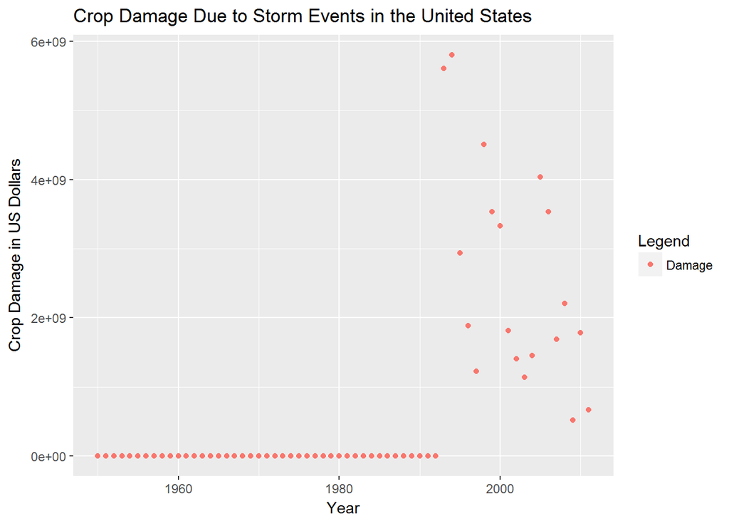

```r
Damage <- numeric(length(unique.years))
i <- 1
for( y in unique.years ) {
  Damage[i] = sum(StormData[StormData$YEARY==y,]$CROPDMGC)
  i <- i+1
}
#print(Damage)
plot.df <- data.frame(unique.years, Damage)
colnames(plot.df) <- c("year", "Damage")
# Now create a ggplot with the data frame
print(
  plot.df %>%
    gather(Legend,Count, Damage) %>%
    ggplot(aes(x=year,y=Count,color=Legend)) + geom_point() +
    labs(x="Year", y="Crop Damage in US Dollars") +
    ggtitle("Crop Damage Due to Storm Events in the United States"))
```

## Body and Property Damage by State

States and their executive and legistlative bodies are responsible for risk assessment with respect to weather, storm, and other such events. Breaking down both life and property events to each state is helpful for state governments to understand what types of events are likely to occur in their states and what the potential risks and costs are for risk assessment planning. Breaking these values also can help the United States Congress to plan the budget to set aside funds for helping states in times of emergency.

```r
# Extract data per state into its own frame
for(st in sort(unique(StormData$STATE))) {
  state.report <- StormData[StormData$STATE==st,]
# Then, get gather body and property damage for each "state"
  fatalities <- injuries <- properties <- crops <-
    vector(mode="numeric", length=length(unique(state.report$EVTYPE)))
  i <- 1
  wkevt <- unique(state.report$EVTYPE)
  for(ev in wkevt) {
    fatalities[i] <- sum(state.report[state.report$EVTYPE==ev,]$FATALITIES)
    injuries[i] <- sum(state.report[state.report$EVTYPE==ev,]$INJURIES)
    properties[i] <- sum(state.report[state.report$EVTYPE==ev,]$PROPDMGC)
    crops[i] <- sum(state.report[state.report$EVTYPE==ev,]$CROPDMGC)
    i <- i+1
  }
  names(fatalities) <- names(injuries) <- names(properties) <- names(crops) <- wkevt
  # Sort each
  fatalities <- sort(fatalities, decreasing=TRUE)
  injuries <- sort(injuries, decreasing=TRUE)
  properties <- sort(properties, decreasing=TRUE)
  crops <- sort(crops, decreasing=TRUE)
  # Create a nice report for each "state"
  cat("##", st, "\n")
  cat("###", "Events of Concern", "\n")
  cat(sprintf("%s  %s",
      "Top events for fatalities, injuries, property damage and crop damage (up to three).",
      "The data includes all recorded weather events from 1950 to November 2011."))

  mnrow <- ifelse(length(fatalities) < 3, length(fatalities), 3)
  df <- data.frame(c(prettyNum(unlist(fatalities[1:mnrow]),scientific=FALSE,big.mark=",")))
  colnames(df) <- c("Number of Fatalities")
  print(knitr::kable(df, caption="Fatalities (1950-2011)"))
  cat("\n")

  mnrow <- ifelse(length(injuries) < 3, length(injuries), 3)
  df <- data.frame(c(prettyNum(unlist(injuries[1:mnrow]),scientific=FALSE,big.mark=",")))
  colnames(df) <- c("Number of Injuries")
  print(knitr::kable(df, caption="Injuries (1950-2011)"))
  cat("\n")

  mnrow <- ifelse(length(properties) < 3, length(properties), 3)
  df <- data.frame(c(prettyNum(unlist(properties[1:mnrow]),scientific=FALSE,big.mark=",")))
  colnames(df) <- c("Property Damage ($)")
  print(knitr::kable(df, caption="Property Damage Costs (1950-2011)"))
  cat("\n")

  mnrow <- ifelse(length(crops) < 3, length(crops), 3)
  df <- data.frame(c(prettyNum(unlist(crops[1:mnrow]),scientific=FALSE,big.mark=",")))
  colnames(df) <- c("Crop Damage ($)")
  print(knitr::kable(df, caption="Crop Damage Costs (1950-2011)"))
  cat("\n")

}
```

## AK

### Events of Concern

Top events for fatalities, injuries, property damage and crop damage (up to three). The data includes all recorded weather events from 1950 to November 2011.

Fatalities (1950-2011)

|  | Number of Fatalities |
| --- | --- |
| AVALANCHE | 33 |
| BLIZZARD | 7 |
| MARINE MISHAP | 7 |

Injuries (1950-2011)

|  | Number of Injuries |
| --- | --- |
| ICE STORM | 34 |
| HIGH WIND | 17 |
| AVALANCHE | 17 |

Property Damage Costs (1950-2011)

|  | Property Damage ($) |
| --- | --- |
| FLOOD | 157,131,940 |
| HIGH WIND | 35,994,150 |
| COASTAL FLOOD | 25,847,060 |

Crop Damage Costs (1950-2011)

|  | Crop Damage ($) |
| --- | --- |
| HIGH WIND | 157,000 |
| HEAVY SNOW | 10,000 |
| HIGH WINDS HEAVY RAINS | 10,000 |

## AL

### Events of Concern

Top events for fatalities, injuries, property damage and crop damage (up to three). The data includes all recorded weather events from 1950 to November 2011.

Fatalities (1950-2011)

|  | Number of Fatalities |
| --- | --- |
| TORNADO | 617 |
| TSTM WIND | 31 |
| LIGHTNING | 28 |

Injuries (1950-2011)

|  | Number of Injuries |
| --- | --- |
| TORNADO | 7,929 |
| TSTM WIND | 336 |
| LIGHTNING | 154 |

Property Damage Costs (1950-2011)

|  | Property Damage ($) |
| --- | --- |
| TORNADO | 6,321,296,560 |
| WINTER STORM | 5,002,033,000 |
| HURRICANE/TYPHOON | 3,621,500,000 |

Crop Damage Costs (1950-2011)

|  | Crop Damage ($) |
| --- | --- |
| HEAT | 400,100,000 |
| TORNADO | 56,797,500 |
| EXTREME COLD | 52,000,000 |

## AM

### Events of Concern

Top events for fatalities, injuries, property damage and crop damage (up to three). The data includes all recorded weather events from 1950 to November 2011.

Fatalities (1950-2011)

|  | Number of Fatalities |
| --- | --- |
| MARINE THUNDERSTORM WIND | 6 |
| MARINE TSTM WIND | 3 |
| MARINE STRONG WIND | 1 |

Injuries (1950-2011)

|  | Number of Injuries |
| --- | --- |
| MARINE THUNDERSTORM WIND | 22 |
| MARINE TSTM WIND | 8 |
| WATERSPOUT | 0 |

Property Damage Costs (1950-2011)

|  | Property Damage ($) |
| --- | --- |
| WATERSPOUT | 5,102,000 |
| MARINE TSTM WIND | 500,000 |
| MARINE THUNDERSTORM WIND | 51,800 |

Crop Damage Costs (1950-2011)

|  | Crop Damage ($) |
| --- | --- |
| MARINE THUNDERSTORM WIND | 50,000 |
| WATERSPOUT | 0 |
| MARINE TSTM WIND | 0 |

## AN

### Events of Concern

Top events for fatalities, injuries, property damage and crop damage (up to three). The data includes all recorded weather events from 1950 to November 2011.

Fatalities (1950-2011)

|  | Number of Fatalities |
| --- | --- |
| MARINE TSTM WIND | 6 |
| MARINE STRONG WIND | 4 |
| MARINE HIGH WIND | 1 |

Injuries (1950-2011)

|  | Number of Injuries |
| --- | --- |
| MARINE STRONG WIND | 18 |
| MARINE THUNDERSTORM WIND | 3 |
| WATERSPOUT | 1 |

Property Damage Costs (1950-2011)

|  | Property Damage ($) |
| --- | --- |
| MARINE THUNDERSTORM WIND | 169,000 |
| MARINE HIGH WIND | 85,000 |
| MARINE TSTM WIND | 20,000 |

Crop Damage Costs (1950-2011)

|  | Crop Damage ($) |
| --- | --- |
| MARINE TSTM WIND | 0 |
| WATERSPOUT | 0 |
| MARINE HAIL | 0 |

## AR

### Events of Concern

Top events for fatalities, injuries, property damage and crop damage (up to three). The data includes all recorded weather events from 1950 to November 2011.

Fatalities (1950-2011)

|  | Number of Fatalities |
| --- | --- |
| TORNADO | 379 |
| FLASH FLOOD | 49 |
| EXCESSIVE HEAT | 19 |

Injuries (1950-2011)

|  | Number of Injuries |
| --- | --- |
| TORNADO | 5,116 |
| TSTM WIND | 188 |
| LIGHTNING | 79 |

Property Damage Costs (1950-2011)

|  | Property Damage ($) |
| --- | --- |
| TORNADO | 2,590,007,310 |
| ICE STORM | 687,091,000 |
| FLOOD | 337,934,000 |

Crop Damage Costs (1950-2011)

|  | Crop Damage ($) |
| --- | --- |
| FLOOD | 141,065,000 |
| HAIL | 9,463,000 |
| HURRICANE/TYPHOON | 7,700,000 |

## AS

### Events of Concern

Top events for fatalities, injuries, property damage and crop damage (up to three). The data includes all recorded weather events from 1950 to November 2011.

Fatalities (1950-2011)

|  | Number of Fatalities |
| --- | --- |
| TSUNAMI | 32 |
| RIP CURRENT | 4 |
| FLASH FLOOD | 4 |

Injuries (1950-2011)

|  | Number of Injuries |
| --- | --- |
| TSUNAMI | 129 |
| HURRICANE/TYPHOON | 20 |
| HEAVY SURF/HIGH SURF | 6 |

Property Damage Costs (1950-2011)

|  | Property Damage ($) |
| --- | --- |
| TSUNAMI | 81,000,000 |
| HURRICANE/TYPHOON | 60,050,000 |
| FLASH FLOOD | 50,362,000 |

Crop Damage Costs (1950-2011)

|  | Crop Damage ($) |
| --- | --- |
| FLASH FLOOD | 1,267,000 |
| HURRICANE | 500,000 |
| TROPICAL STORM | 500,000 |

## AZ

### Events of Concern

Top events for fatalities, injuries, property damage and crop damage (up to three). The data includes all recorded weather events from 1950 to November 2011.

Fatalities (1950-2011)

|  | Number of Fatalities |
| --- | --- |
| FLASH FLOOD | 62 |
| EXCESSIVE HEAT | 55 |
| LIGHTNING | 18 |

Injuries (1950-2011)

|  | Number of Injuries |
| --- | --- |
| DUST STORM | 179 |
| TSTM WIND | 152 |
| FLASH FLOOD | 150 |

Property Damage Costs (1950-2011)

|  | Property Damage ($) |
| --- | --- |
| HAIL | 2,828,908,700 |
| TSTM WIND | 383,328,100 |
| WILDFIRE | 222,285,000 |

Crop Damage Costs (1950-2011)

|  | Crop Damage ($) |
| --- | --- |
| TROPICAL STORM | 200,000,000 |
| FLASH FLOOD | 8,005,000 |
| FLOOD | 5,500,000 |

## CA

### Events of Concern

Top events for fatalities, injuries, property damage and crop damage (up to three). The data includes all recorded weather events from 1950 to November 2011.

Fatalities (1950-2011)

|  | Number of Fatalities |
| --- | --- |
| EXCESSIVE HEAT | 110 |
| FLASH FLOOD | 36 |
| HIGH SURF | 35 |

Injuries (1950-2011)

|  | Number of Injuries |
| --- | --- |
| WILDFIRE | 623 |
| FOG | 408 |
| WILD/FOREST FIRE | 355 |

Property Damage Costs (1950-2011)

|  | Property Damage ($) |
| --- | --- |
| FLOOD | 116,751,420,000 |
| WILDFIRE | 3,452,953,830 |
| WILD/FOREST FIRE | 956,834,000 |

Crop Damage Costs (1950-2011)

|  | Crop Damage ($) |
| --- | --- |
| EXTREME COLD | 731,160,000 |
| HEAVY RAIN | 681,131,000 |
| FLOOD | 626,375,000 |

## CO

### Events of Concern

Top events for fatalities, injuries, property damage and crop damage (up to three). The data includes all recorded weather events from 1950 to November 2011.

Fatalities (1950-2011)

|  | Number of Fatalities |
| --- | --- |
| LIGHTNING | 48 |
| AVALANCHE | 48 |
| FLASH FLOOD | 12 |

Injuries (1950-2011)

|  | Number of Injuries |
| --- | --- |
| TORNADO | 261 |
| LIGHTNING | 260 |
| HAIL | 121 |

Property Damage Costs (1950-2011)

|  | Property Damage ($) |
| --- | --- |
| HAIL | 1,426,944,800 |
| FLASH FLOOD | 411,428,075 |
| TORNADO | 287,529,440 |

Crop Damage Costs (1950-2011)

|  | Crop Damage ($) |
| --- | --- |
| HAIL | 116,490,000 |
| THUNDERSTORM WIND | 18,065,000 |
| Freeze | 10,500,000 |

## CT

### Events of Concern

Top events for fatalities, injuries, property damage and crop damage (up to three). The data includes all recorded weather events from 1950 to November 2011.

Fatalities (1950-2011)

|  | Number of Fatalities |
| --- | --- |
| HIGH WIND | 6 |
| FLOOD | 5 |
| TORNADO | 4 |

Injuries (1950-2011)

|  | Number of Injuries |
| --- | --- |
| TORNADO | 703 |
| LIGHTNING | 59 |
| WINTER WEATHER | 47 |

Property Damage Costs (1950-2011)

|  | Property Damage ($) |
| --- | --- |
| TORNADO | 596,236,620 |
| TROPICAL STORM | 60,004,000 |
| FLOOD | 29,358,000 |

Crop Damage Costs (1950-2011)

|  | Crop Damage ($) |
| --- | --- |
| HAIL | 30,000 |
| TORNADO | 0 |
| TSTM WIND | 0 |

## DC

### Events of Concern

Top events for fatalities, injuries, property damage and crop damage (up to three). The data includes all recorded weather events from 1950 to November 2011.

Fatalities (1950-2011)

|  | Number of Fatalities |
| --- | --- |
| EXCESSIVE HEAT | 20 |
| TSTM WIND | 2 |
| COLD WEATHER | 2 |

Injuries (1950-2011)

|  | Number of Injuries |
| --- | --- |
| EXCESSIVE HEAT | 316 |
| TSTM WIND | 15 |
| LIGHTNING | 12 |

Property Damage Costs (1950-2011)

|  | Property Damage ($) |
| --- | --- |
| TROPICAL STORM | 127,600,000 |
| FLASH FLOOD | 16,095,000 |
| FLOOD | 10,000,000 |

Crop Damage Costs (1950-2011)

|  | Crop Damage ($) |
| --- | --- |
| DROUGHT | 5,000 |
| HAIL | 0 |
| TSTM WIND | 0 |

## DE

### Events of Concern

Top events for fatalities, injuries, property damage and crop damage (up to three). The data includes all recorded weather events from 1950 to November 2011.

Fatalities (1950-2011)

|  | Number of Fatalities |
| --- | --- |
| EXCESSIVE HEAT | 7 |
| FLASH FLOOD | 6 |
| WINTER STORM | 5 |

Injuries (1950-2011)

|  | Number of Injuries |
| --- | --- |
| TORNADO | 73 |
| HIGH SURF | 63 |
| EXCESSIVE HEAT | 51 |

Property Damage Costs (1950-2011)

|  | Property Damage ($) |
| --- | --- |
| COASTAL FLOOD | 40,150,000 |
| FLASH FLOOD | 27,654,000 |
| TROPICAL STORM | 17,750,000 |

Crop Damage Costs (1950-2011)

|  | Crop Damage ($) |
| --- | --- |
| DROUGHT | 29,100,000 |
| HAIL | 300,000 |
| THUNDERSTORM WIND | 201,000 |

## FL

### Events of Concern

Top events for fatalities, injuries, property damage and crop damage (up to three). The data includes all recorded weather events from 1950 to November 2011.

Fatalities (1950-2011)

|  | Number of Fatalities |
| --- | --- |
| RIP CURRENT | 172 |
| TORNADO | 161 |
| LIGHTNING | 123 |

Injuries (1950-2011)

|  | Number of Injuries |
| --- | --- |
| TORNADO | 3,340 |
| LIGHTNING | 858 |
| HURRICANE/TYPHOON | 802 |

Property Damage Costs (1950-2011)

|  | Property Damage ($) |
| --- | --- |
| HURRICANE/TYPHOON | 27,596,865,000 |
| HURRICANE OPAL | 3,104,571,000 |
| HIGH WIND | 3,089,931,000 |

Crop Damage Costs (1950-2011)

|  | Crop Damage ($) |
| --- | --- |
| HURRICANE/TYPHOON | 955,200,000 |
| FLOOD | 679,507,500 |
| FROST/FREEZE | 483,150,000 |

## GA

### Events of Concern

Top events for fatalities, injuries, property damage and crop damage (up to three). The data includes all recorded weather events from 1950 to November 2011.

Fatalities (1950-2011)

|  | Number of Fatalities |
| --- | --- |
| TORNADO | 180 |
| LIGHTNING | 30 |
| FLOOD | 27 |

Injuries (1950-2011)

|  | Number of Injuries |
| --- | --- |
| TORNADO | 3,926 |
| BLIZZARD | 402 |
| LIGHTNING | 254 |

Property Damage Costs (1950-2011)

|  | Property Damage ($) |
| --- | --- |
| TORNADO | 3,261,026,670 |
| FLOOD | 528,577,250 |
| HAIL | 254,326,600 |

Crop Damage Costs (1950-2011)

|  | Crop Damage ($) |
| --- | --- |
| DROUGHT | 717,285,000 |
| FROST/FREEZE | 160,500,000 |
| BLIZZARD | 105,000,000 |

## GM

### Events of Concern

Top events for fatalities, injuries, property damage and crop damage (up to three). The data includes all recorded weather events from 1950 to November 2011.

Fatalities (1950-2011)

|  | Number of Fatalities |
| --- | --- |
| MARINE THUNDERSTORM WIND | 1 |
| MARINE TSTM WIND | 0 |
| WATERSPOUT | 0 |

Injuries (1950-2011)

|  | Number of Injuries |
| --- | --- |
| MARINE TSTM WIND | 0 |
| WATERSPOUT | 0 |
| MARINE HAIL | 0 |

Property Damage Costs (1950-2011)

|  | Property Damage ($) |
| --- | --- |
| MARINE TSTM WIND | 3,226,000 |
| MARINE THUNDERSTORM WIND | 166,100 |
| WATERSPOUT | 110,200 |

Crop Damage Costs (1950-2011)

|  | Crop Damage ($) |
| --- | --- |
| MARINE TSTM WIND | 0 |
| WATERSPOUT | 0 |
| MARINE HAIL | 0 |

## GU

### Events of Concern

Top events for fatalities, injuries, property damage and crop damage (up to three). The data includes all recorded weather events from 1950 to November 2011.

Fatalities (1950-2011)

|  | Number of Fatalities |
| --- | --- |
| RIP CURRENT | 20 |
| HEAVY RAIN | 19 |
| RIP CURRENTS | 18 |

Injuries (1950-2011)

|  | Number of Injuries |
| --- | --- |
| HURRICANE/TYPHOON | 333 |
| RIP CURRENTS | 46 |
| RIP CURRENT | 9 |

Property Damage Costs (1950-2011)

|  | Property Damage ($) |
| --- | --- |
| TYPHOON | 600,230,000 |
| HURRICANE/TYPHOON | 212,690,000 |
| HURRICANE | 101,170,000 |

Crop Damage Costs (1950-2011)

|  | Crop Damage ($) |
| --- | --- |
| HURRICANE | 100,480,000 |
| HURRICANE/TYPHOON | 4,270,000 |
| STORM SURGE/TIDE | 850,000 |

## HI

### Events of Concern

Top events for fatalities, injuries, property damage and crop damage (up to three). The data includes all recorded weather events from 1950 to November 2011.

Fatalities (1950-2011)

|  | Number of Fatalities |
| --- | --- |
| HIGH SURF | 21 |
| FLASH FLOOD | 10 |
| HEAVY SURF/HIGH SURF | 4 |

Injuries (1950-2011)

|  | Number of Injuries |
| --- | --- |
| STRONG WIND | 20 |
| HIGH SURF | 18 |
| HEAVY SURF/HIGH SURF | 10 |

Property Damage Costs (1950-2011)

|  | Property Damage ($) |
| --- | --- |
| FLASH FLOOD | 156,508,000 |
| TSUNAMI | 14,200,000 |
| Heavy Rain/High Surf | 13,500,000 |

Crop Damage Costs (1950-2011)

|  | Crop Damage ($) |
| --- | --- |
| HIGH WIND | 2,600,000 |
| WILDFIRE | 2,265,000 |
| Heavy Rain/High Surf | 1,500,000 |

## IA

### Events of Concern

Top events for fatalities, injuries, property damage and crop damage (up to three). The data includes all recorded weather events from 1950 to November 2011.

Fatalities (1950-2011)

|  | Number of Fatalities |
| --- | --- |
| TORNADO | 81 |
| TSTM WIND | 9 |
| LIGHTNING | 9 |

Injuries (1950-2011)

|  | Number of Injuries |
| --- | --- |
| TORNADO | 2,208 |
| TSTM WIND | 220 |
| HAIL | 134 |

Property Damage Costs (1950-2011)

|  | Property Damage ($) |
| --- | --- |
| TORNADO | 2,286,576,650 |
| FLOOD | 1,381,403,000 |
| DROUGHT | 645,150,000 |

Crop Damage Costs (1950-2011)

|  | Crop Damage ($) |
| --- | --- |
| DROUGHT | 2,009,630,000 |
| FLOOD | 1,588,826,000 |
| HAIL | 294,938,450 |

## ID

### Events of Concern

Top events for fatalities, injuries, property damage and crop damage (up to three). The data includes all recorded weather events from 1950 to November 2011.

Fatalities (1950-2011)

|  | Number of Fatalities |
| --- | --- |
| AVALANCHE | 16 |
| TSTM WIND | 8 |
| LIGHTNING | 7 |

Injuries (1950-2011)

|  | Number of Injuries |
| --- | --- |
| THUNDERSTORM WIND | 74 |
| TSTM WIND | 66 |
| LIGHTNING | 26 |

Property Damage Costs (1950-2011)

|  | Property Damage ($) |
| --- | --- |
| FLOOD | 114,192,000 |
| HEAVY RAIN | 50,840,000 |
| FLASH FLOOD | 14,767,000 |

Crop Damage Costs (1950-2011)

|  | Crop Damage ($) |
| --- | --- |
| TSTM WIND/HAIL | 6,002,000 |
| FROST | 5,000,000 |
| COOL AND WET | 5,000,000 |

## IL

### Events of Concern

Top events for fatalities, injuries, property damage and crop damage (up to three). The data includes all recorded weather events from 1950 to November 2011.

Fatalities (1950-2011)

|  | Number of Fatalities |
| --- | --- |
| HEAT | 653 |
| EXCESSIVE HEAT | 330 |
| TORNADO | 203 |

Injuries (1950-2011)

|  | Number of Injuries |
| --- | --- |
| TORNADO | 4,145 |
| TSTM WIND | 381 |
| EXCESSIVE HEAT | 352 |

Property Damage Costs (1950-2011)

|  | Property Damage ($) |
| --- | --- |
| RIVER FLOOD | 5,021,900,000 |
| TORNADO | 1,780,613,840 |
| FLASH FLOOD | 796,675,550 |

Crop Damage Costs (1950-2011)

|  | Crop Damage ($) |
| --- | --- |
| RIVER FLOOD | 5,012,500,000 |
| DROUGHT | 284,570,000 |
| TSTM WIND | 91,499,000 |

## IN

### Events of Concern

Top events for fatalities, injuries, property damage and crop damage (up to three). The data includes all recorded weather events from 1950 to November 2011.

Fatalities (1950-2011)

|  | Number of Fatalities |
| --- | --- |
| TORNADO | 252 |
| FLOOD | 24 |
| FLASH FLOOD | 18 |

Injuries (1950-2011)

|  | Number of Injuries |
| --- | --- |
| TORNADO | 4,224 |
| TSTM WIND | 207 |
| LIGHTNING | 89 |

Property Damage Costs (1950-2011)

|  | Property Damage ($) |
| --- | --- |
| TORNADO | 2,594,793,890 |
| FLOOD | 848,982,750 |
| FLASH FLOOD | 318,731,200 |

Crop Damage Costs (1950-2011)

|  | Crop Damage ($) |
| --- | --- |
| FLOOD | 698,198,000 |
| FLASH FLOOD | 92,709,500 |
| DROUGHT | 73,000,000 |

## KS

### Events of Concern

Top events for fatalities, injuries, property damage and crop damage (up to three). The data includes all recorded weather events from 1950 to November 2011.

Fatalities (1950-2011)

|  | Number of Fatalities |
| --- | --- |
| TORNADO | 236 |
| FLASH FLOOD | 16 |
| ICE STORM | 16 |

Injuries (1950-2011)

|  | Number of Injuries |
| --- | --- |
| TORNADO | 2,721 |
| TSTM WIND | 268 |
| HAIL | 121 |

Property Damage Costs (1950-2011)

|  | Property Damage ($) |
| --- | --- |
| TORNADO | 2,669,890,670 |
| HAIL | 506,525,350 |
| FLASH FLOOD | 295,417,350 |

Crop Damage Costs (1950-2011)

|  | Crop Damage ($) |
| --- | --- |
| HAIL | 259,405,300 |
| DROUGHT | 155,954,000 |
| FLOOD | 86,789,000 |

## KY

### Events of Concern

Top events for fatalities, injuries, property damage and crop damage (up to three). The data includes all recorded weather events from 1950 to November 2011.

Fatalities (1950-2011)

|  | Number of Fatalities |
| --- | --- |
| TORNADO | 125 |
| FLASH FLOOD | 40 |
| FLOOD | 19 |

Injuries (1950-2011)

|  | Number of Injuries |
| --- | --- |
| TORNADO | 2,806 |
| TSTM WIND | 249 |
| EXCESSIVE HEAT | 138 |

Property Damage Costs (1950-2011)

|  | Property Damage ($) |
| --- | --- |
| TORNADO | 888,768,680 |
| HAIL | 611,068,100 |
| FLOOD | 547,811,000 |

Crop Damage Costs (1950-2011)

|  | Crop Damage ($) |
| --- | --- |
| DROUGHT | 226,000,000 |
| FLASH FLOOD | 22,136,500 |
| HIGH WIND | 15,300,000 |

## LA

### Events of Concern

Top events for fatalities, injuries, property damage and crop damage (up to three). The data includes all recorded weather events from 1950 to November 2011.

Fatalities (1950-2011)

|  | Number of Fatalities |
| --- | --- |
| TORNADO | 153 |
| EXCESSIVE HEAT | 55 |
| LIGHTNING | 24 |

Injuries (1950-2011)

|  | Number of Injuries |
| --- | --- |
| TORNADO | 2,637 |
| TSTM WIND | 244 |
| LIGHTNING | 117 |

Property Damage Costs (1950-2011)

|  | Property Damage ($) |
| --- | --- |
| STORM SURGE | 31,742,735,000 |
| HURRICANE/TYPHOON | 20,995,910,000 |
| HEAVY RAIN/SEVERE WEATHER | 2,500,000,000 |

Crop Damage Costs (1950-2011)

|  | Crop Damage ($) |
| --- | --- |
| DROUGHT | 587,430,000 |
| HURRICANE | 338,000,000 |
| TROPICAL STORM | 154,600,000 |

## LC

### Events of Concern

Top events for fatalities, injuries, property damage and crop damage (up to three). The data includes all recorded weather events from 1950 to November 2011.

Fatalities (1950-2011)

|  | Number of Fatalities |
| --- | --- |
| MARINE TSTM WIND | 0 |
| MARINE HAIL | 0 |
| MARINE THUNDERSTORM WIND | 0 |

Injuries (1950-2011)

|  | Number of Injuries |
| --- | --- |
| MARINE TSTM WIND | 0 |
| MARINE HAIL | 0 |
| MARINE THUNDERSTORM WIND | 0 |

Property Damage Costs (1950-2011)

|  | Property Damage ($) |
| --- | --- |
| MARINE TSTM WIND | 0 |
| MARINE HAIL | 0 |
| MARINE THUNDERSTORM WIND | 0 |

Crop Damage Costs (1950-2011)

|  | Crop Damage ($) |
| --- | --- |
| MARINE TSTM WIND | 0 |
| MARINE HAIL | 0 |
| MARINE THUNDERSTORM WIND | 0 |

## LE

### Events of Concern

Top events for fatalities, injuries, property damage and crop damage (up to three). The data includes all recorded weather events from 1950 to November 2011.

Fatalities (1950-2011)

|  | Number of Fatalities |
| --- | --- |
| MARINE TSTM WIND | 0 |
| WATERSPOUT | 0 |
| MARINE HAIL | 0 |

Injuries (1950-2011)

|  | Number of Injuries |
| --- | --- |
| MARINE TSTM WIND | 0 |
| WATERSPOUT | 0 |
| MARINE HAIL | 0 |

Property Damage Costs (1950-2011)

|  | Property Damage ($) |
| --- | --- |
| MARINE THUNDERSTORM WIND | 25,000 |
| MARINE TSTM WIND | 5,000 |
| WATERSPOUT | 0 |

Crop Damage Costs (1950-2011)

|  | Crop Damage ($) |
| --- | --- |
| MARINE TSTM WIND | 0 |
| WATERSPOUT | 0 |
| MARINE HAIL | 0 |

## LH

### Events of Concern

Top events for fatalities, injuries, property damage and crop damage (up to three). The data includes all recorded weather events from 1950 to November 2011.

Fatalities (1950-2011)

|  | Number of Fatalities |
| --- | --- |
| WATERSPOUT | 0 |
| MARINE TSTM WIND | 0 |
| MARINE HAIL | 0 |

Injuries (1950-2011)

|  | Number of Injuries |
| --- | --- |
| WATERSPOUT | 0 |
| MARINE TSTM WIND | 0 |
| MARINE HAIL | 0 |

Property Damage Costs (1950-2011)

|  | Property Damage ($) |
| --- | --- |
| WATERSPOUT | 0 |
| MARINE TSTM WIND | 0 |
| MARINE HAIL | 0 |

Crop Damage Costs (1950-2011)

|  | Crop Damage ($) |
| --- | --- |
| WATERSPOUT | 0 |
| MARINE TSTM WIND | 0 |
| MARINE HAIL | 0 |

## LM

### Events of Concern

Top events for fatalities, injuries, property damage and crop damage (up to three). The data includes all recorded weather events from 1950 to November 2011.

Fatalities (1950-2011)

|  | Number of Fatalities |
| --- | --- |
| MARINE STRONG WIND | 2 |
| MARINE THUNDERSTORM WIND | 2 |
| MARINE TSTM WIND | 0 |

Injuries (1950-2011)

|  | Number of Injuries |
| --- | --- |
| MARINE STRONG WIND | 1 |
| MARINE THUNDERSTORM WIND | 1 |
| MARINE TSTM WIND | 0 |

Property Damage Costs (1950-2011)

|  | Property Damage ($) |
| --- | --- |
| MARINE TSTM WIND | 1,205,000 |
| MARINE HIGH WIND | 1,110,000 |
| MARINE STRONG WIND | 312,600 |

Crop Damage Costs (1950-2011)

|  | Crop Damage ($) |
| --- | --- |
| MARINE TSTM WIND | 0 |
| WATERSPOUT | 0 |
| MARINE HAIL | 0 |

## LO

### Events of Concern

Top events for fatalities, injuries, property damage and crop damage (up to three). The data includes all recorded weather events from 1950 to November 2011.

Fatalities (1950-2011)

|  | Number of Fatalities |
| --- | --- |
| MARINE TSTM WIND | 0 |
| WATERSPOUT | 0 |
| MARINE THUNDERSTORM WIND | 0 |

Injuries (1950-2011)

|  | Number of Injuries |
| --- | --- |
| MARINE TSTM WIND | 0 |
| WATERSPOUT | 0 |
| MARINE THUNDERSTORM WIND | 0 |

Property Damage Costs (1950-2011)

|  | Property Damage ($) |
| --- | --- |
| MARINE TSTM WIND | 50,000 |
| MARINE THUNDERSTORM WIND | 20,000 |
| WATERSPOUT | 0 |

Crop Damage Costs (1950-2011)

|  | Crop Damage ($) |
| --- | --- |
| MARINE TSTM WIND | 0 |
| WATERSPOUT | 0 |
| MARINE THUNDERSTORM WIND | 0 |

## LS

### Events of Concern

Top events for fatalities, injuries, property damage and crop damage (up to three). The data includes all recorded weather events from 1950 to November 2011.

Fatalities (1950-2011)

|  | Number of Fatalities |
| --- | --- |
| MARINE STRONG WIND | 1 |
| WATERSPOUT | 0 |
| MARINE TSTM WIND | 0 |

Injuries (1950-2011)

|  | Number of Injuries |
| --- | --- |
| WATERSPOUT | 0 |
| MARINE TSTM WIND | 0 |
| MARINE HAIL | 0 |

Property Damage Costs (1950-2011)

|  | Property Damage ($) |
| --- | --- |
| MARINE TSTM WIND | 400,000 |
| WATERSPOUT | 0 |
| MARINE HAIL | 0 |

Crop Damage Costs (1950-2011)

|  | Crop Damage ($) |
| --- | --- |
| WATERSPOUT | 0 |
| MARINE TSTM WIND | 0 |
| MARINE HAIL | 0 |

## MA

### Events of Concern

Top events for fatalities, injuries, property damage and crop damage (up to three). The data includes all recorded weather events from 1950 to November 2011.

Fatalities (1950-2011)

|  | Number of Fatalities |
| --- | --- |
| TORNADO | 108 |
| TSTM WIND | 8 |
| LIGHTNING | 6 |

Injuries (1950-2011)

|  | Number of Injuries |
| --- | --- |
| TORNADO | 1,758 |
| LIGHTNING | 171 |
| TSTM WIND | 97 |

Property Damage Costs (1950-2011)

|  | Property Damage ($) |
| --- | --- |
| TORNADO | 756,039,370 |
| FLOOD | 227,335,000 |
| HEAVY SNOW | 73,974,000 |

Crop Damage Costs (1950-2011)

|  | Crop Damage ($) |
| --- | --- |
| THUNDERSTORM WIND | 1,250,000 |
| HAIL | 100,000 |
| TSTM WIND | 10,000 |

## MD

### Events of Concern

Top events for fatalities, injuries, property damage and crop damage (up to three). The data includes all recorded weather events from 1950 to November 2011.

Fatalities (1950-2011)

|  | Number of Fatalities |
| --- | --- |
| EXCESSIVE HEAT | 88 |
| LIGHTNING | 13 |
| FLASH FLOOD | 12 |

Injuries (1950-2011)

|  | Number of Injuries |
| --- | --- |
| EXCESSIVE HEAT | 461 |
| TORNADO | 314 |
| TROPICAL STORM | 200 |

Property Damage Costs (1950-2011)

|  | Property Damage ($) |
| --- | --- |
| TROPICAL STORM | 538,505,000 |
| TORNADO | 331,924,500 |
| FLOOD | 67,444,000 |

Crop Damage Costs (1950-2011)

|  | Crop Damage ($) |
| --- | --- |
| DROUGHT | 99,720,000 |
| HEAT WAVE | 4,700,000 |
| AGRICULTURAL FREEZE | 1,480,000 |

## ME

### Events of Concern

Top events for fatalities, injuries, property damage and crop damage (up to three). The data includes all recorded weather events from 1950 to November 2011.

Fatalities (1950-2011)

|  | Number of Fatalities |
| --- | --- |
| LIGHTNING | 6 |
| FLOOD | 4 |
| STRONG WINDS | 3 |

Injuries (1950-2011)

|  | Number of Injuries |
| --- | --- |
| LIGHTNING | 70 |
| FOG | 24 |
| TORNADO | 19 |

Property Damage Costs (1950-2011)

|  | Property Damage ($) |
| --- | --- |
| ICE STORM | 318,230,000 |
| FLOOD | 120,673,700 |
| FLASH FLOOD | 62,800,000 |

Crop Damage Costs (1950-2011)

|  | Crop Damage ($) |
| --- | --- |
| HEAVY RAINS | 500,000 |
| HAIL | 130,000 |
| FLASH FLOOD | 5,000 |

## MH

### Events of Concern

Top events for fatalities, injuries, property damage and crop damage (up to three). The data includes all recorded weather events from 1950 to November 2011.

Fatalities (1950-2011)

|  | Number of Fatalities |
| --- | --- |
| HIGH SURF | 0 |

Injuries (1950-2011)

|  | Number of Injuries |
| --- | --- |
| HIGH SURF | 1 |

Property Damage Costs (1950-2011)

|  | Property Damage ($) |
| --- | --- |
| HIGH SURF | 5,000,000 |

Crop Damage Costs (1950-2011)

|  | Crop Damage ($) |
| --- | --- |
| HIGH SURF | 0 |

## MI

### Events of Concern

Top events for fatalities, injuries, property damage and crop damage (up to three). The data includes all recorded weather events from 1950 to November 2011.

Fatalities (1950-2011)

|  | Number of Fatalities |
| --- | --- |
| TORNADO | 243 |
| TSTM WIND | 40 |
| LIGHTNING | 19 |

Injuries (1950-2011)

|  | Number of Injuries |
| --- | --- |
| TORNADO | 3,362 |
| TSTM WIND | 322 |
| HEAT | 315 |

Property Damage Costs (1950-2011)

|  | Property Damage ($) |
| --- | --- |
| TORNADO | 1,071,765,550 |
| HAIL | 287,678,800 |
| TSTM WIND | 240,281,950 |

Crop Damage Costs (1950-2011)

|  | Crop Damage ($) |
| --- | --- |
| DROUGHT | 150,000,000 |
| TSTM WIND | 39,223,000 |
| HAIL | 20,024,000 |

## MN

### Events of Concern

Top events for fatalities, injuries, property damage and crop damage (up to three). The data includes all recorded weather events from 1950 to November 2011.

Fatalities (1950-2011)

|  | Number of Fatalities |
| --- | --- |
| TORNADO | 99 |
| FLASH FLOOD | 13 |
| EXCESSIVE HEAT | 13 |

Injuries (1950-2011)

|  | Number of Injuries |
| --- | --- |
| TORNADO | 1,976 |
| TSTM WIND | 92 |
| LIGHTNING | 70 |

Property Damage Costs (1950-2011)

|  | Property Damage ($) |
| --- | --- |
| TORNADO | 1,903,701,140 |
| FLOOD | 1,293,248,800 |
| HAIL | 923,515,700 |

Crop Damage Costs (1950-2011)

|  | Crop Damage ($) |
| --- | --- |
| HAIL | 140,700,800 |
| FLOOD | 104,715,000 |
| TSTM WIND | 28,108,550 |

## MO

### Events of Concern

Top events for fatalities, injuries, property damage and crop damage (up to three). The data includes all recorded weather events from 1950 to November 2011.

Fatalities (1950-2011)

|  | Number of Fatalities |
| --- | --- |
| TORNADO | 388 |
| EXCESSIVE HEAT | 190 |
| FLASH FLOOD | 72 |

Injuries (1950-2011)

|  | Number of Injuries |
| --- | --- |
| TORNADO | 4,330 |
| EXCESSIVE HEAT | 3,525 |
| HEAT | 660 |

Property Damage Costs (1950-2011)

|  | Property Damage ($) |
| --- | --- |
| TORNADO | 4,800,631,770 |
| HAIL | 1,136,027,370 |
| FLASH FLOOD | 679,421,230 |

Crop Damage Costs (1950-2011)

|  | Crop Damage ($) |
| --- | --- |
| FLOOD | 593,040,000 |
| FLASH FLOOD | 62,693,300 |
| DROUGHT | 30,835,000 |

## MS

### Events of Concern

Top events for fatalities, injuries, property damage and crop damage (up to three). The data includes all recorded weather events from 1950 to November 2011.

Fatalities (1950-2011)

|  | Number of Fatalities |
| --- | --- |
| TORNADO | 450 |
| EXCESSIVE HEAT | 24 |
| LIGHTNING | 16 |

Injuries (1950-2011)

|  | Number of Injuries |
| --- | --- |
| TORNADO | 6,244 |
| TSTM WIND | 216 |
| HURRICANE/TYPHOON | 104 |

Property Damage Costs (1950-2011)

|  | Property Damage ($) |
| --- | --- |
| HURRICANE/TYPHOON | 13,492,735,000 |
| STORM SURGE | 11,265,030,000 |
| TORNADO | 2,441,964,530 |

Crop Damage Costs (1950-2011)

|  | Crop Damage ($) |
| --- | --- |
| ICE STORM | 5,000,060,000 |
| HURRICANE/TYPHOON | 1,514,980,800 |
| TORNADO | 54,135,000 |

## MT

### Events of Concern

Top events for fatalities, injuries, property damage and crop damage (up to three). The data includes all recorded weather events from 1950 to November 2011.

Fatalities (1950-2011)

|  | Number of Fatalities |
| --- | --- |
| LIGHTNING | 9 |
| AVALANCHE | 8 |
| FLOOD | 5 |

Injuries (1950-2011)

|  | Number of Injuries |
| --- | --- |
| WILD/FOREST FIRE | 33 |
| LIGHTNING | 30 |
| TSTM WIND | 23 |

Property Damage Costs (1950-2011)

|  | Property Damage ($) |
| --- | --- |
| HAIL | 94,729,700 |
| TORNADO | 86,600,150 |
| FLOOD | 38,020,400 |

Crop Damage Costs (1950-2011)

|  | Crop Damage ($) |
| --- | --- |
| HAIL | 34,345,000 |
| THUNDERSTORM WIND | 6,019,000 |
| ICE JAM FLOODING | 5,000,000 |

## NC

### Events of Concern

Top events for fatalities, injuries, property damage and crop damage (up to three). The data includes all recorded weather events from 1950 to November 2011.

Fatalities (1950-2011)

|  | Number of Fatalities |
| --- | --- |
| TORNADO | 126 |
| FLASH FLOOD | 38 |
| LIGHTNING | 29 |

Injuries (1950-2011)

|  | Number of Injuries |
| --- | --- |
| TORNADO | 2,536 |
| LIGHTNING | 278 |
| WINTER STORM | 191 |

Property Damage Costs (1950-2011)

|  | Property Damage ($) |
| --- | --- |
| HURRICANE | 4,979,861,000 |
| TORNADO | 1,551,333,680 |
| FLASH FLOOD | 788,463,050 |

Crop Damage Costs (1950-2011)

|  | Crop Damage ($) |
| --- | --- |
| HURRICANE | 1,425,130,000 |
| FLASH FLOOD | 149,850,000 |
| HIGH WIND | 140,094,000 |

## ND

### Events of Concern

Top events for fatalities, injuries, property damage and crop damage (up to three). The data includes all recorded weather events from 1950 to November 2011.

Fatalities (1950-2011)

|  | Number of Fatalities |
| --- | --- |
| TORNADO | 25 |
| BLIZZARD | 9 |
| FLOOD | 5 |

Injuries (1950-2011)

|  | Number of Injuries |
| --- | --- |
| TORNADO | 326 |
| BLIZZARD | 97 |
| TSTM WIND | 47 |

Property Damage Costs (1950-2011)

|  | Property Damage ($) |
| --- | --- |
| FLOOD | 3,916,842,000 |
| HAIL | 472,663,600 |
| BLIZZARD | 224,558,000 |

Crop Damage Costs (1950-2011)

|  | Crop Damage ($) |
| --- | --- |
| HAIL | 189,355,030 |
| THUNDERSTORM WIND | 175,603,000 |
| FLOOD | 72,960,000 |

## NE

### Events of Concern

Top events for fatalities, injuries, property damage and crop damage (up to three). The data includes all recorded weather events from 1950 to November 2011.

Fatalities (1950-2011)

|  | Number of Fatalities |
| --- | --- |
| TORNADO | 54 |
| WINTER STORM | 11 |
| LIGHTNING | 6 |

Injuries (1950-2011)

|  | Number of Injuries |
| --- | --- |
| TORNADO | 1,158 |
| HAIL | 93 |
| TSTM WIND | 85 |

Property Damage Costs (1950-2011)

|  | Property Damage ($) |
| --- | --- |
| TORNADO | 1,718,164,710 |
| HAIL | 920,898,250 |
| FLASH FLOOD | 97,992,700 |

Crop Damage Costs (1950-2011)

|  | Crop Damage ($) |
| --- | --- |
| HAIL | 737,993,650 |
| DROUGHT | 720,000,000 |
| DAMAGING FREEZE | 262,000,000 |

## NH

### Events of Concern

Top events for fatalities, injuries, property damage and crop damage (up to three). The data includes all recorded weather events from 1950 to November 2011.

Fatalities (1950-2011)

|  | Number of Fatalities |
| --- | --- |
| TSTM WIND | 6 |
| FLASH FLOOD | 4 |
| EXTREME COLD | 4 |

Injuries (1950-2011)

|  | Number of Injuries |
| --- | --- |
| LIGHTNING | 85 |
| TORNADO | 30 |
| TSTM WIND | 30 |

Property Damage Costs (1950-2011)

|  | Property Damage ($) |
| --- | --- |
| ICE STORM | 64,934,000 |
| FLOOD | 61,313,270 |
| FLASH FLOOD | 36,898,000 |

Crop Damage Costs (1950-2011)

|  | Crop Damage ($) |
| --- | --- |
| FLOOD | 200,000 |
| TORNADO | 0 |
| TSTM WIND | 0 |

## NJ

### Events of Concern

Top events for fatalities, injuries, property damage and crop damage (up to three). The data includes all recorded weather events from 1950 to November 2011.

Fatalities (1950-2011)

|  | Number of Fatalities |
| --- | --- |
| EXCESSIVE HEAT | 39 |
| FLOOD | 19 |
| LIGHTNING | 15 |

Injuries (1950-2011)

|  | Number of Injuries |
| --- | --- |
| EXCESSIVE HEAT | 300 |
| FLASH FLOOD | 190 |
| TSTM WIND | 168 |

Property Damage Costs (1950-2011)

|  | Property Damage ($) |
| --- | --- |
| FLOOD | 2,111,650,000 |
| FLASH FLOOD | 733,210,000 |
| TORNADO | 79,214,250 |

Crop Damage Costs (1950-2011)

|  | Crop Damage ($) |
| --- | --- |
| DROUGHT | 80,000,000 |
| HAIL | 17,112,000 |
| TSTM WIND | 1,200,000 |

## NM

### Events of Concern

Top events for fatalities, injuries, property damage and crop damage (up to three). The data includes all recorded weather events from 1950 to November 2011.

Fatalities (1950-2011)

|  | Number of Fatalities |
| --- | --- |
| FLASH FLOOD | 16 |
| LIGHTNING | 12 |
| HIGH WIND | 8 |

Injuries (1950-2011)

|  | Number of Injuries |
| --- | --- |
| TORNADO | 155 |
| LIGHTNING | 52 |
| HAIL | 40 |

Property Damage Costs (1950-2011)

|  | Property Damage ($) |
| --- | --- |
| WILD/FOREST FIRE | 1,509,700,000 |
| HAIL | 124,469,850 |
| WILDFIRES | 100,000,000 |

Crop Damage Costs (1950-2011)

|  | Crop Damage ($) |
| --- | --- |
| DROUGHT | 14,400,000 |
| HAIL | 7,073,600 |
| FLASH FLOOD | 5,380,000 |

## NV

### Events of Concern

Top events for fatalities, injuries, property damage and crop damage (up to three). The data includes all recorded weather events from 1950 to November 2011.

Fatalities (1950-2011)

|  | Number of Fatalities |
| --- | --- |
| HEAT | 54 |
| EXCESSIVE HEAT | 13 |
| TSTM WIND | 4 |

Injuries (1950-2011)

|  | Number of Injuries |
| --- | --- |
| FLOOD | 50 |
| DUST STORM | 49 |
| HIGH WIND | 33 |

Property Damage Costs (1950-2011)

|  | Property Damage ($) |
| --- | --- |
| FLOOD | 677,945,000 |
| FLASH FLOOD | 59,319,100 |
| THUNDERSTORM WIND | 51,769,200 |

Crop Damage Costs (1950-2011)

|  | Crop Damage ($) |
| --- | --- |
| FLOOD | 6,000,000 |
| HAIL | 100,000 |
| HIGH WIND | 100,000 |

## NY

### Events of Concern

Top events for fatalities, injuries, property damage and crop damage (up to three). The data includes all recorded weather events from 1950 to November 2011.

Fatalities (1950-2011)

|  | Number of Fatalities |
| --- | --- |
| EXCESSIVE HEAT | 93 |
| FLASH FLOOD | 38 |
| TSTM WIND | 27 |

Injuries (1950-2011)

|  | Number of Injuries |
| --- | --- |
| TORNADO | 315 |
| TSTM WIND | 278 |
| LIGHTNING | 244 |

Property Damage Costs (1950-2011)

|  | Property Damage ($) |
| --- | --- |
| FLASH FLOOD | 1,831,088,500 |
| FLOOD | 1,326,149,490 |
| TORNADO | 466,573,840 |

Crop Damage Costs (1950-2011)

|  | Crop Damage ($) |
| --- | --- |
| DROUGHT | 100,200,000 |
| HAIL | 87,375,600 |
| TSTM WIND | 11,387,000 |

## OH

### Events of Concern

Top events for fatalities, injuries, property damage and crop damage (up to three). The data includes all recorded weather events from 1950 to November 2011.

Fatalities (1950-2011)

|  | Number of Fatalities |
| --- | --- |
| TORNADO | 191 |
| FLASH FLOOD | 34 |
| LIGHTNING | 32 |

Injuries (1950-2011)

|  | Number of Injuries |
| --- | --- |
| TORNADO | 4,438 |
| ICE STORM | 1,652 |
| TSTM WIND | 221 |

Property Damage Costs (1950-2011)

|  | Property Damage ($) |
| --- | --- |
| TORNADO | 2,279,857,790 |
| FLASH FLOOD | 1,307,961,720 |
| WINTER STORM | 927,810,000 |

Crop Damage Costs (1950-2011)

|  | Crop Damage ($) |
| --- | --- |
| DROUGHT | 200,000,000 |
| FLOOD | 88,853,000 |
| FLASH FLOOD | 43,255,000 |

## OK

### Events of Concern

Top events for fatalities, injuries, property damage and crop damage (up to three). The data includes all recorded weather events from 1950 to November 2011.

Fatalities (1950-2011)

|  | Number of Fatalities |
| --- | --- |
| TORNADO | 296 |
| EXCESSIVE HEAT | 63 |
| FLASH FLOOD | 32 |

Injuries (1950-2011)

|  | Number of Injuries |
| --- | --- |
| TORNADO | 4,829 |
| TSTM WIND | 191 |
| FLASH FLOOD | 170 |

Property Damage Costs (1950-2011)

|  | Property Damage ($) |
| --- | --- |
| TORNADO | 3,268,708,260 |
| THUNDERSTORM WIND | 775,240,750 |
| ICE STORM | 688,090,000 |

Crop Damage Costs (1950-2011)

|  | Crop Damage ($) |
| --- | --- |
| DROUGHT | 1,097,040,000 |
| TORNADO | 50,556,550 |
| FLOOD | 50,260,000 |

## OR

### Events of Concern

Top events for fatalities, injuries, property damage and crop damage (up to three). The data includes all recorded weather events from 1950 to November 2011.

Fatalities (1950-2011)

|  | Number of Fatalities |
| --- | --- |
| HIGH WIND | 19 |
| FLOOD | 16 |
| HIGH SURF | 12 |

Injuries (1950-2011)

|  | Number of Injuries |
| --- | --- |
| HIGH WIND | 50 |
| ICE STORM | 33 |
| HEAVY SNOW | 22 |

Property Damage Costs (1950-2011)

|  | Property Damage ($) |
| --- | --- |
| FLOOD | 722,172,500 |
| HIGH WIND | 108,649,650 |
| HAIL | 52,607,700 |

Crop Damage Costs (1950-2011)

|  | Crop Damage ($) |
| --- | --- |
| HAIL | 36,028,000 |
| DROUGHT | 22,600,000 |
| FLOOD | 18,860,000 |

## PA

### Events of Concern

Top events for fatalities, injuries, property damage and crop damage (up to three). The data includes all recorded weather events from 1950 to November 2011.

Fatalities (1950-2011)

|  | Number of Fatalities |
| --- | --- |
| EXCESSIVE HEAT | 359 |
| HEAT WAVE | 107 |
| TORNADO | 82 |

Injuries (1950-2011)

|  | Number of Injuries |
| --- | --- |
| TORNADO | 1,241 |
| EXCESSIVE HEAT | 320 |
| HEAVY SNOW | 303 |

Property Damage Costs (1950-2011)

|  | Property Damage ($) |
| --- | --- |
| TORNADO | 1,789,038,400 |
| FLASH FLOOD | 1,410,799,570 |
| FLOOD | 1,078,667,000 |

Crop Damage Costs (1950-2011)

|  | Crop Damage ($) |
| --- | --- |
| DROUGHT | 539,400,000 |
| EXTREME COLD | 25,000,000 |
| UNSEASONABLY COLD | 25,000,000 |

## PH

### Events of Concern

Top events for fatalities, injuries, property damage and crop damage (up to three). The data includes all recorded weather events from 1950 to November 2011.

Fatalities (1950-2011)

|  | Number of Fatalities |
| --- | --- |
| MARINE STRONG WIND | 1 |
| WATERSPOUT | 0 |
| MARINE TSTM WIND | 0 |

Injuries (1950-2011)

|  | Number of Injuries |
| --- | --- |
| WATERSPOUT | 0 |
| MARINE TSTM WIND | 0 |
| MARINE STRONG WIND | 0 |

Property Damage Costs (1950-2011)

|  | Property Damage ($) |
| --- | --- |
| WATERSPOUT | 0 |
| MARINE TSTM WIND | 0 |
| MARINE STRONG WIND | 0 |

Crop Damage Costs (1950-2011)

|  | Crop Damage ($) |
| --- | --- |
| WATERSPOUT | 0 |
| MARINE TSTM WIND | 0 |
| MARINE STRONG WIND | 0 |

## PK

### Events of Concern

Top events for fatalities, injuries, property damage and crop damage (up to three). The data includes all recorded weather events from 1950 to November 2011.

Fatalities (1950-2011)

|  | Number of Fatalities |
| --- | --- |
| MARINE TSTM WIND | 0 |
| MARINE HIGH WIND | 0 |
| WATERSPOUT | 0 |

Injuries (1950-2011)

|  | Number of Injuries |
| --- | --- |
| MARINE TSTM WIND | 0 |
| MARINE HIGH WIND | 0 |
| WATERSPOUT | 0 |

Property Damage Costs (1950-2011)

|  | Property Damage ($) |
| --- | --- |
| MARINE HIGH WIND | 31,000 |
| MARINE TSTM WIND | 0 |
| WATERSPOUT | 0 |

Crop Damage Costs (1950-2011)

|  | Crop Damage ($) |
| --- | --- |
| MARINE TSTM WIND | 0 |
| MARINE HIGH WIND | 0 |
| WATERSPOUT | 0 |

## PM

### Events of Concern

Top events for fatalities, injuries, property damage and crop damage (up to three). The data includes all recorded weather events from 1950 to November 2011.

Fatalities (1950-2011)

|  | Number of Fatalities |
| --- | --- |
| WATERSPOUT | 0 |

Injuries (1950-2011)

|  | Number of Injuries |
| --- | --- |
| WATERSPOUT | 0 |

Property Damage Costs (1950-2011)

|  | Property Damage ($) |
| --- | --- |
| WATERSPOUT | 0 |

Crop Damage Costs (1950-2011)

|  | Crop Damage ($) |
| --- | --- |
| WATERSPOUT | 0 |

## PR

### Events of Concern

Top events for fatalities, injuries, property damage and crop damage (up to three). The data includes all recorded weather events from 1950 to November 2011.

Fatalities (1950-2011)

|  | Number of Fatalities |
| --- | --- |
| FLASH FLOOD | 34 |
| HURRICANE | 19 |
| HEAVY RAIN | 13 |

Injuries (1950-2011)

|  | Number of Injuries |
| --- | --- |
| HEAVY RAIN | 10 |
| HIGH SURF | 9 |
| THUNDERSTORM WIND | 7 |

Property Damage Costs (1950-2011)

|  | Property Damage ($) |
| --- | --- |
| HURRICANE | 1,824,431,000 |
| FLASH FLOOD | 198,087,650 |
| FLOOD | 113,589,000 |

Crop Damage Costs (1950-2011)

|  | Crop Damage ($) |
| --- | --- |
| HURRICANE | 451,000,000 |
| TROPICAL STORM | 103,605,000 |
| FLOOD | 48,000,000 |

## PZ

### Events of Concern

Top events for fatalities, injuries, property damage and crop damage (up to three). The data includes all recorded weather events from 1950 to November 2011.

Fatalities (1950-2011)

|  | Number of Fatalities |
| --- | --- |
| MARINE STRONG WIND | 5 |
| WATERSPOUT | 0 |
| MARINE TSTM WIND | 0 |

Injuries (1950-2011)

|  | Number of Injuries |
| --- | --- |
| MARINE STRONG WIND | 3 |
| WATERSPOUT | 0 |
| MARINE TSTM WIND | 0 |

Property Damage Costs (1950-2011)

|  | Property Damage ($) |
| --- | --- |
| MARINE STRONG WIND | 76,000 |
| WATERSPOUT | 0 |
| MARINE TSTM WIND | 0 |

Crop Damage Costs (1950-2011)

|  | Crop Damage ($) |
| --- | --- |
| WATERSPOUT | 0 |
| MARINE TSTM WIND | 0 |
| MARINE STRONG WIND | 0 |

## RI

### Events of Concern

Top events for fatalities, injuries, property damage and crop damage (up to three). The data includes all recorded weather events from 1950 to November 2011.

Fatalities (1950-2011)

|  | Number of Fatalities |
| --- | --- |
| HEAT | 2 |
| HIGH SURF | 2 |
| LIGHTNING | 1 |

Injuries (1950-2011)

|  | Number of Injuries |
| --- | --- |
| TORNADO | 23 |
| LIGHTNING | 17 |
| HIGH WIND | 5 |

Property Damage Costs (1950-2011)

|  | Property Damage ($) |
| --- | --- |
| FLOOD | 92,860,000 |
| HEAVY SNOW | 11,340,000 |
| HIGH WINDS | 5,050,000 |

Crop Damage Costs (1950-2011)

|  | Crop Damage ($) |
| --- | --- |
| HAIL | 0 |
| TSTM WIND | 0 |
| TORNADO | 0 |

## SC

### Events of Concern

Top events for fatalities, injuries, property damage and crop damage (up to three). The data includes all recorded weather events from 1950 to November 2011.

Fatalities (1950-2011)

|  | Number of Fatalities |
| --- | --- |
| TORNADO | 59 |
| EXCESSIVE HEAT | 29 |
| LIGHTNING | 24 |

Injuries (1950-2011)

|  | Number of Injuries |
| --- | --- |
| TORNADO | 1,314 |
| TSTM WIND | 185 |
| LIGHTNING | 105 |

Property Damage Costs (1950-2011)

|  | Property Damage ($) |
| --- | --- |
| TORNADO | 531,505,190 |
| ICE STORM | 153,207,500 |
| HIGH WINDS/COLD | 110,500,000 |

Crop Damage Costs (1950-2011)

|  | Crop Damage ($) |
| --- | --- |
| HURRICANE | 20,300,000 |
| EXTREME COLD | 20,050,000 |
| DROUGHT | 20,000,000 |

## SD

### Events of Concern

Top events for fatalities, injuries, property damage and crop damage (up to three). The data includes all recorded weather events from 1950 to November 2011.

Fatalities (1950-2011)

|  | Number of Fatalities |
| --- | --- |
| TORNADO | 18 |
| ICE STORM | 8 |
| BLIZZARD | 6 |

Injuries (1950-2011)

|  | Number of Injuries |
| --- | --- |
| TORNADO | 452 |
| TSTM WIND | 77 |
| ICE STORM | 67 |

Property Damage Costs (1950-2011)

|  | Property Damage ($) |
| --- | --- |
| TORNADO | 231,213,780 |
| HAIL | 97,992,050 |
| FLASH FLOOD | 94,233,200 |

Crop Damage Costs (1950-2011)

|  | Crop Damage ($) |
| --- | --- |
| HAIL | 64,274,050 |
| FLASH FLOOD | 50,765,500 |
| FLOOD | 28,171,000 |

## SL

### Events of Concern

Top events for fatalities, injuries, property damage and crop damage (up to three). The data includes all recorded weather events from 1950 to November 2011.

Fatalities (1950-2011)

|  | Number of Fatalities |
| --- | --- |
| MARINE TSTM WIND | 0 |
| MARINE HAIL | 0 |

Injuries (1950-2011)

|  | Number of Injuries |
| --- | --- |
| MARINE TSTM WIND | 0 |
| MARINE HAIL | 0 |

Property Damage Costs (1950-2011)

|  | Property Damage ($) |
| --- | --- |
| MARINE TSTM WIND | 15,000 |
| MARINE HAIL | 0 |

Crop Damage Costs (1950-2011)

|  | Crop Damage ($) |
| --- | --- |
| MARINE TSTM WIND | 0 |
| MARINE HAIL | 0 |

## ST

### Events of Concern

Top events for fatalities, injuries, property damage and crop damage (up to three). The data includes all recorded weather events from 1950 to November 2011.

Fatalities (1950-2011)

|  | Number of Fatalities |
| --- | --- |
| STRONG WINDS | 0 |

Injuries (1950-2011)

|  | Number of Injuries |
| --- | --- |
| STRONG WINDS | 0 |

Property Damage Costs (1950-2011)

|  | Property Damage ($) |
| --- | --- |
| STRONG WINDS | 0 |

Crop Damage Costs (1950-2011)

|  | Crop Damage ($) |
| --- | --- |
| STRONG WINDS | 0 |

## TN

### Events of Concern

Top events for fatalities, injuries, property damage and crop damage (up to three). The data includes all recorded weather events from 1950 to November 2011.

Fatalities (1950-2011)

|  | Number of Fatalities |
| --- | --- |
| TORNADO | 368 |
| FLOOD | 35 |
| EXCESSIVE HEAT | 21 |

Injuries (1950-2011)

|  | Number of Injuries |
| --- | --- |
| TORNADO | 4,748 |
| TSTM WIND | 190 |
| LIGHTNING | 108 |

Property Damage Costs (1950-2011)

|  | Property Damage ($) |
| --- | --- |
| FLOOD | 4,245,346,300 |
| TORNADO | 1,541,799,890 |
| FLASH FLOOD | 360,268,370 |

Crop Damage Costs (1950-2011)

|  | Crop Damage ($) |
| --- | --- |
| TSTM WIND | 9,146,500 |
| WINTER STORM | 5,000,000 |
| FLOOD | 4,197,000 |

## TX

### Events of Concern

Top events for fatalities, injuries, property damage and crop damage (up to three). The data includes all recorded weather events from 1950 to November 2011.

Fatalities (1950-2011)

|  | Number of Fatalities |
| --- | --- |
| TORNADO | 538 |
| EXCESSIVE HEAT | 269 |
| FLASH FLOOD | 177 |

Injuries (1950-2011)

|  | Number of Injuries |
| --- | --- |
| TORNADO | 8,207 |
| FLOOD | 6,338 |
| FLASH FLOOD | 587 |

Property Damage Costs (1950-2011)

|  | Property Damage ($) |
| --- | --- |
| TROPICAL STORM | 5,491,193,000 |
| STORM SURGE/TIDE | 4,500,385,000 |
| TORNADO | 3,720,875,840 |

Crop Damage Costs (1950-2011)

|  | Crop Damage ($) |
| --- | --- |
| DROUGHT | 6,373,438,000 |
| HAIL | 456,694,600 |
| WILDFIRE | 161,796,400 |

## UT

### Events of Concern

Top events for fatalities, injuries, property damage and crop damage (up to three). The data includes all recorded weather events from 1950 to November 2011.

Fatalities (1950-2011)

|  | Number of Fatalities |
| --- | --- |
| AVALANCHE | 44 |
| LIGHTNING | 22 |
| WINTER STORM | 20 |

Injuries (1950-2011)

|  | Number of Injuries |
| --- | --- |
| WINTER STORM | 415 |
| HEAVY SNOW | 259 |
| TORNADO | 91 |

Property Damage Costs (1950-2011)

|  | Property Damage ($) |
| --- | --- |
| FLOOD | 331,761,500 |
| TORNADO | 174,812,920 |
| HEAVY SNOW | 54,460,750 |

Crop Damage Costs (1950-2011)

|  | Crop Damage ($) |
| --- | --- |
| HIGH WIND | 1,110,000 |
| HIGH WINDS | 1,000,000 |
| FLASH FLOOD | 823,700 |

## VA

### Events of Concern

Top events for fatalities, injuries, property damage and crop damage (up to three). The data includes all recorded weather events from 1950 to November 2011.

Fatalities (1950-2011)

|  | Number of Fatalities |
| --- | --- |
| TORNADO | 36 |
| FLASH FLOOD | 29 |
| LIGHTNING | 22 |

Injuries (1950-2011)

|  | Number of Injuries |
| --- | --- |
| TORNADO | 914 |
| EXCESSIVE HEAT | 230 |
| TSTM WIND | 131 |

Property Damage Costs (1950-2011)

|  | Property Damage ($) |
| --- | --- |
| HURRICANE/TYPHOON | 512,000,000 |
| TORNADO | 439,239,250 |
| FLASH FLOOD | 237,396,970 |

Crop Damage Costs (1950-2011)

|  | Crop Damage ($) |
| --- | --- |
| DROUGHT | 297,480,000 |
| HURRICANE | 45,410,000 |
| FLOOD/FLASH FLOOD | 39,879,000 |

## VI

### Events of Concern

Top events for fatalities, injuries, property damage and crop damage (up to three). The data includes all recorded weather events from 1950 to November 2011.

Fatalities (1950-2011)

|  | Number of Fatalities |
| --- | --- |
| HIGH SURF | 3 |
| RIP CURRENTS | 2 |
| HIGH SEAS | 1 |

Injuries (1950-2011)

|  | Number of Injuries |
| --- | --- |
| RIP CURRENTS | 1 |
| LIGHTNING | 1 |
| FLOOD | 0 |

Property Damage Costs (1950-2011)

|  | Property Damage ($) |
| --- | --- |
| HURRICANE | 28,220,000 |
| TROPICAL STORM | 6,250,000 |
| FLASH FLOOD | 1,960,000 |

Crop Damage Costs (1950-2011)

|  | Crop Damage ($) |
| --- | --- |
| DROUGHT | 200,000 |
| TROPICAL STORM | 5,000 |
| FLOOD | 0 |

## VT

### Events of Concern

Top events for fatalities, injuries, property damage and crop damage (up to three). The data includes all recorded weather events from 1950 to November 2011.

Fatalities (1950-2011)

|  | Number of Fatalities |
| --- | --- |
| FLOOD | 4 |
| TSTM WIND | 3 |
| FLASH FLOOD | 3 |

Injuries (1950-2011)

|  | Number of Injuries |
| --- | --- |
| TSTM WIND | 24 |
| TORNADO | 10 |
| THUNDERSTORM WINDS | 10 |

Property Damage Costs (1950-2011)

|  | Property Damage ($) |
| --- | --- |
| FLOOD | 1,100,484,000 |
| FLASH FLOOD | 325,039,000 |
| WINTER STORM | 15,564,650 |

Crop Damage Costs (1950-2011)

|  | Crop Damage ($) |
| --- | --- |
| FLASH FLOOD | 14,725,000 |
| FLOOD | 11,950,000 |
| FROST | 5,000,000 |

## WA

### Events of Concern

Top events for fatalities, injuries, property damage and crop damage (up to three). The data includes all recorded weather events from 1950 to November 2011.

Fatalities (1950-2011)

|  | Number of Fatalities |
| --- | --- |
| AVALANCHE | 35 |
| HIGH WIND | 34 |
| HEAVY SNOW | 8 |

Injuries (1950-2011)

|  | Number of Injuries |
| --- | --- |
| TORNADO | 303 |
| HIGH WIND | 73 |
| ICE | 72 |

Property Damage Costs (1950-2011)

|  | Property Damage ($) |
| --- | --- |
| FLOOD | 212,683,000 |
| HEAVY RAIN | 189,855,500 |
| HIGH WIND | 148,408,000 |

Crop Damage Costs (1950-2011)

|  | Crop Damage ($) |
| --- | --- |
| HAIL | 209,501,000 |
| FROST/FREEZE | 205,020,000 |
| WILD/FOREST FIRE | 82,756,000 |

## WI

### Events of Concern

Top events for fatalities, injuries, property damage and crop damage (up to three). The data includes all recorded weather events from 1950 to November 2011.

Fatalities (1950-2011)

|  | Number of Fatalities |
| --- | --- |
| TORNADO | 96 |
| EXTREME HEAT | 67 |
| EXCESSIVE HEAT | 27 |

Injuries (1950-2011)

|  | Number of Injuries |
| --- | --- |
| TORNADO | 1,601 |
| TSTM WIND | 166 |
| LIGHTNING | 120 |

Property Damage Costs (1950-2011)

|  | Property Damage ($) |
| --- | --- |
| HAIL | 961,723,350 |
| TORNADO | 958,093,080 |
| FLASH FLOOD | 837,156,860 |

Crop Damage Costs (1950-2011)

|  | Crop Damage ($) |
| --- | --- |
| FLOOD | 466,888,500 |
| FLASH FLOOD | 350,690,000 |
| HAIL | 56,132,850 |

## WV

### Events of Concern

Top events for fatalities, injuries, property damage and crop damage (up to three). The data includes all recorded weather events from 1950 to November 2011.

Fatalities (1950-2011)

|  | Number of Fatalities |
| --- | --- |
| FLASH FLOOD | 24 |
| FLOOD | 13 |
| TSTM WIND | 10 |

Injuries (1950-2011)

|  | Number of Injuries |
| --- | --- |
| TSTM WIND | 142 |
| TORNADO | 114 |
| LIGHTNING | 48 |

Property Damage Costs (1950-2011)

|  | Property Damage ($) |
| --- | --- |
| FLASH FLOOD | 485,226,100 |
| FLOOD | 273,982,000 |
| HEAVY SNOW | 68,887,000 |

Crop Damage Costs (1950-2011)

|  | Crop Damage ($) |
| --- | --- |
| DROUGHT | 19,746,000 |
| AGRICULTURAL FREEZE | 9,380,000 |
| TORNADO | 2,306,000 |

## WY

### Events of Concern

Top events for fatalities, injuries, property damage and crop damage (up to three). The data includes all recorded weather events from 1950 to November 2011.

Fatalities (1950-2011)

|  | Number of Fatalities |
| --- | --- |
| AVALANCHE | 23 |
| LIGHTNING | 8 |
| WINTER STORM | 6 |

Injuries (1950-2011)

|  | Number of Injuries |
| --- | --- |
| WINTER STORM | 119 |
| TORNADO | 101 |
| LIGHTNING | 72 |

Property Damage Costs (1950-2011)

|  | Property Damage ($) |
| --- | --- |
| HAIL | 111,226,700 |
| TORNADO | 47,617,110 |
| FLOOD | 15,739,500 |

Crop Damage Costs (1950-2011)

|  | Crop Damage ($) |
| --- | --- |
| HAIL | 1,881,200 |
| FLOOD | 1,140,000 |
| EXTREME COLD | 150,000 |

## XX

### Events of Concern

Top events for fatalities, injuries, property damage and crop damage (up to three). The data includes all recorded weather events from 1950 to November 2011.

Fatalities (1950-2011)

|  | Number of Fatalities |
| --- | --- |
| MARINE THUNDERSTORM WIND | 0 |

Injuries (1950-2011)

|  | Number of Injuries |
| --- | --- |
| MARINE THUNDERSTORM WIND | 0 |

Property Damage Costs (1950-2011)

|  | Property Damage ($) |
| --- | --- |
| MARINE THUNDERSTORM WIND | 0 |

Crop Damage Costs (1950-2011)

|  | Crop Damage ($) |
| --- | --- |
| MARINE THUNDERSTORM WIND | 0 |